# 1. Import the MNIST Dataset.

```python
import tensorflow as tf
import matplotlib.pyplot as plt

mnist = tf.keras.datasets.mnist
(x_train, y_train),(x_test, y_test) = mnist.load_data()
```

```
Downloading data from https://storage.googleapis.com/tensorflow/tf-keras-datasets/mnist.npz
```

# 2. MNIST Dataset

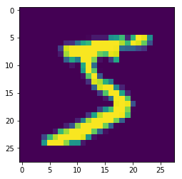

```python
plt.imshow(x_train[0])
plt.show()
```

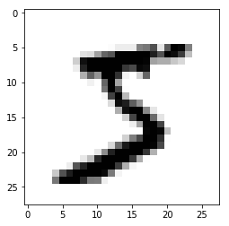

```python
plt.imshow(x_train[0], cmap = plt.cm.binary)
plt.show()
```

# 3. Sequential Model - Normalize

```python
x_train = tf.keras.utils.normalize(x_train, axis=1)
x_test = tf.keras.utils.normalize(x_test, axis=1)
```

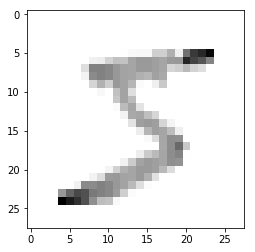

```python
plt.imshow(x_train[0], cmap = plt.cm.binary)
plt.show()
```

# 3. Input (32,32,10), SGD, batch_size=64, epochs=20

```python
model = tf.keras.models.Sequential()
model.add(tf.keras.layers.Flatten())
model.add(tf.keras.layers.Dense(32, activation=tf.nn.relu))
model.add(tf.keras.layers.Dense(32, activation=tf.nn.relu))
model.add(tf.keras.layers.Dense(10, activation=tf.nn.softmax))

from keras import optimizers

sgd = optimizers.SGD()
model.compile(optimizer='sgd', loss='sparse_categorical_crossentropy', metrics=['accuracy'])
model.fit(x_train, y_train, batch_size=64, epochs=20)
```

```
Train on 60000 samples
```

```
<tensorflow.python.keras.callbacks.History at 0x25aaff54748>
```

```python
val_loss, val_acc = model.evaluate(x_test, y_test)
print("Validation Accuracy: "+str(val_acc))
```

```
Validation Accuracy: 0.937
```

```python
predictions = model.predict([x_test])
```

```python
print(predictions)
```

```
[[9.73212627e-06 1.25599300e-07 7.07117666e-04 ... 9.96481419e-01
  1.16260060e-06 7.62079144e-05]
 [2.83717585e-04 4.52270004e-04 9.86150086e-01 ... 3.65136671e-10
  2.43056129e-04 2.51890973e-11]
 [1.91952381e-07 9.97459948e-01 5.42321417e-04 ... 2.19743670e-04
  9.73697461e-04 3.27786875e-05]
 ...
 [6.48240857e-08 1.88459962e-05 1.00796215e-05 ... 4.77399357e-04
  3.79088498e-03 1.18911592e-02]
 [2.07536141e-04 4.87227917e-05 1.03505408e-06 ... 4.84856002e-07
  4.64795753e-02 3.91939602e-06]
 [2.69137614e-04 1.29105308e-06 3.55077558e-03 ... 3.66304000e-08
  4.97732981e-05 9.02434323e-08]]
```

```python
import numpy as np

print(np.argmax([predictions[0]]))
```

```
7
```

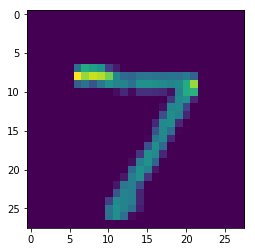

```python
plt.imshow(x_test[0])
plt.show()
```

# 4. Output(64,64,10)

When the number of nuerons are increased, the time taken to train the model increases. The accuracy here didn't change significantly.

```python
model = tf.keras.models.Sequential()
model.add(tf.keras.layers.Flatten())
model.add(tf.keras.layers.Dense(64, activation=tf.nn.relu))
model.add(tf.keras.layers.Dense(64, activation=tf.nn.relu))
model.add(tf.keras.layers.Dense(10, activation=tf.nn.softmax))

from keras import optimizers

sgd = optimizers.SGD()
model.compile(optimizer='sgd', loss='sparse_categorical_crossentropy', metrics=['accuracy'])
model.fit(x_train, y_train, batch_size=64, epochs=20)

val_loss, val_acc = model.evaluate(x_test, y_test)
print("Validation Accuracy: "+str(val_acc))
```

```
Train on 60000 samples
Validation Accuracy: 0.9425
```

# 5.Output(32,32,10), SGD(lr=0.01, decay_rate=0.000001, momentum_rate=0.9)

```python
model = tf.keras.models.Sequential()
model.add(tf.keras.layers.Flatten())
model.add(tf.keras.layers.Dense(32, activation=tf.nn.relu))
model.add(tf.keras.layers.Dense(32, activation=tf.nn.relu))
model.add(tf.keras.layers.Dense(10, activation=tf.nn.softmax))

from keras import optimizers

sgd = optimizers.SGD(lr=0.01, decay=0.000001, momentum=0.9)
model.compile(optimizer='sgd', loss='sparse_categorical_crossentropy', metrics=['accuracy'])
model.fit(x_train, y_train, batch_size=64, epochs=20)

val_loss, val_acc = model.evaluate(x_test, y_test)
print("Validation Accuracy: "+str(val_acc))
```

```
Train on 60000 samples
Validation Accuracy: 0.9354
```

# Momentum is used for converging in the models. In our case, even if we use the momentum for faster convergence of gradients, there is no change in the accuracy. It is almost the same even without using it.

# 6. Input(32,32,10), batch_size=128 and Input(32,32,10), batch_size=32

```python
model = tf.keras.models.Sequential()
model.add(tf.keras.layers.Flatten())
model.add(tf.keras.layers.Dense(32, activation=tf.nn.relu))
model.add(tf.keras.layers.Dense(32, activation=tf.nn.relu))
model.add(tf.keras.layers.Dense(10, activation=tf.nn.softmax))

from keras import optimizers

sgd = optimizers.SGD(lr=0.01, decay=0.000001, momentum=0.9)
model.compile(optimizer='sgd', loss='sparse_categorical_crossentropy', metrics=['accuracy'])
model.fit(x_train, y_train, batch_size=128, epochs=20)

val_loss, val_acc = model.evaluate(x_test, y_test)
print("Validation Accuracy: "+str(val_acc))
```

```
Train on 60000 samples
Validation Accuracy: 0.9253
```

```python
model = tf.keras.models.Sequential()
model.add(tf.keras.layers.Flatten())
model.add(tf.keras.layers.Dense(32, activation=tf.nn.relu))
model.add(tf.keras.layers.Dense(32, activation=tf.nn.relu))
model.add(tf.keras.layers.Dense(10, activation=tf.nn.softmax))

from keras import optimizers

sgd = optimizers.SGD(lr=0.01, decay=0.000001, momentum=0.9)
model.compile(optimizer='sgd', loss='sparse_categorical_crossentropy', metrics=['accuracy'])
model.fit(x_train, y_train, batch_size=32, epochs=20)

val_loss, val_acc = model.evaluate(x_test, y_test)
print("Validation Accuracy: "+str(val_acc))
```

```
Train on 60000 samples
Validation Accuracy: 0.9503
```

# 7. Adding hidden layer when input (32,32,32,10)

```python
model = tf.keras.models.Sequential()
model.add(tf.keras.layers.Flatten())
model.add(tf.keras.layers.Dense(32, activation=tf.nn.relu))
model.add(tf.keras.layers.Dense(32, activation=tf.nn.relu))
model.add(tf.keras.layers.Dense(32, activation=tf.nn.relu))
model.add(tf.keras.layers.Dense(10, activation=tf.nn.softmax))

from keras import optimizers

sgd = optimizers.SGD(lr=0.01, decay=0.000001, momentum=0.9)
model.compile(optimizer='sgd', loss='sparse_categorical_crossentropy', metrics=['accuracy'])
model.fit(x_train, y_train, batch_size=32, epochs=20)

val_loss, val_acc = model.evaluate(x_test, y_test)
print("Validation Accuracy: "+str(val_acc))
```

```
Train on 60000 samples
Validation Accuracy: 0.9596
```

# 8. Input (128,128,10) and adding Drop out layer where dropout = 0.5

# Dropout is used to prevent overfitting.

```python
model = tf.keras.models.Sequential()
model.add(tf.keras.layers.Flatten())
model.add(tf.keras.layers.Dropout(rate=0.5, noise_shape=None, seed=None))
model.add(tf.keras.layers.Dense(128, activation=tf.nn.relu))
model.add(tf.keras.layers.Dropout(rate=0.5, noise_shape=None, seed=None))
model.add(tf.keras.layers.Dense(128, activation=tf.nn.relu))
model.add(tf.keras.layers.Dropout(rate=0.5, noise_shape=None, seed=None))
model.add(tf.keras.layers.Dense(10, activation=tf.nn.softmax))

from keras import optimizers

sgd = optimizers.SGD(lr=0.01, decay=0.000001, momentum=0.9)
model.compile(optimizer='sgd', loss='sparse_categorical_crossentropy', metrics=['accuracy'])
model.fit(x_train, y_train, batch_size=32, epochs=20)

val_loss, val_acc = model.evaluate(x_test, y_test)
print("Validation Accuracy: "+str(val_acc))
```

```
Train on 60000 samples
Validation Accuracy: 0.9452
```

# Adding the dropout layer prevents the overfitting which is good for the model not to memorize the patterns. Accuracy is not increased drastically.

1. Model with better parameters

```python
model = tf.keras.models.Sequential()
model.add(tf.keras.layers.Flatten())
#model.add(tf.keras.layers.Dropout(rate=0.5, noise_shape=None, seed=None))
model.add(tf.keras.layers.Dense(32, activation=tf.nn.relu))
#model.add(tf.keras.layers.Dropout(rate=0.5, noise_shape=None, seed=None))
model.add(tf.keras.layers.Dense(32, activation=tf.nn.relu))
#model.add(tf.keras.layers.Dropout(rate=0.5, noise_shape=None, seed=None))
model.add(tf.keras.layers.Dense(10, activation=tf.nn.softmax))

from keras import optimizers

sgd = optimizers.SGD(lr=0.09, decay=0.000001, momentum=0.9)
model.compile(optimizer='sgd', loss='sparse_categorical_crossentropy', metrics=['accuracy'])
model.fit(x_train, y_train, batch_size=32, epochs=20)

val_loss, val_acc = model.evaluate(x_test, y_test)
print("Validation Accuracy: "+str(val_acc))
```

```
Train on 60000 samples
Validation Accuracy: 0.954
```

Question 10 -

Given the data, below parameters are important a. Number of hidden layers b. Number of neurons per layer c. Batch_size d. Learning rate